# Assignment 03

Hyperparameter Tunning - Group 4

Authors

Landon Carpenter

Georgetown University

Nakul R. Padalkar

Georgetown University

Michael Varnerin

Georgetown University

Minsuh Lim

Georgetown University

Jingda Yang

Georgetown University

Published

October 25, 2023

Modified

October 27, 2023

# 1 Instructions (removed)

# 2 Grading Criteria

- The assignment is worth 75 points.
- There are three grading milestones in the assignment.
  - Adherence to Requirements, Coding Standards, Documentation, Runtime, and Efficiency (22 Points)
    - Adherence to Requirements (5 Points): Ensure all the given requirements of the assignment, including Git commits and collaboration, are met.
    - Coding Standards (5 Points): Code should be readable and maintainable. Ensure appropriate variable naming and code commenting.
    - Documentation (6 Points): Provide explanations or reasoning for using a particular command and describe the outputs. Avoid vague descriptions; aim for clarity and depth.
    - Runtime (3 Points): The code should execute without errors and handle possible exceptions.
    - Efficiency (3 Points): Implement efficient coding practices, avoid redundancy, and optimize for performance where applicable.
  - Collaborative Programming (13 Points)
    - GitHub Repository Structure (3 Points): A well-organized repository with clear directory structures and meaningful file names.
    - Number of Commits (3 Points): Reflects steady progress and contributions from all group members.
    - Commit Quality (3 Points): Clear, descriptive commit messages representing logical chunks of work. Avoid trivial commits like “typo fix.”
    - Collaboration & Contribution (4 Points): Demonstrated teamwork where each member contributes significantly. This can be seen through pull requests, code reviews, and merge activities.
  - Assignment Questions (40 Points)

# 3 Adherence to Requirements, Coding Standards, Documentation, Runtime, and Efficiency (22 Points)

This section is graded based on adherence to Requirements, Coding Standards, Documentation, Runtime, and Efficiency.

# 4 Collaborative Programming (13 Points)

This section is graded based on the Github submission. Each person needs to have made commits to the repository. GitHub Repository Structure, Number of Commits, Commit Quality, Collaboration, and Contribution are generally graded based on the group’s overall performance. However, if there is a significant difference in the number of commits or contributions between group members, the instructor may adjust the grade accordingly.

# 5 Assignment Questions (40 Points)

# 6 Data Preparation (7 Points):

## 6.1 Load the dataset and display the dataframe (2 Points).

```python
import pandas as pd

df_shopping = pd.read_csv("online_shoppers_intention.csv")

print(df_shopping.head())
```

```
   Administrative  Administrative_Duration  Informational  \
0               0                      0.0              0
1               0                      0.0              0
2               0                      0.0              0
3               0                      0.0              0
4               0                      0.0              0

   Informational_Duration  ProductRelated  ProductRelated_Duration  \
0                     0.0               1                 0.000000
1                     0.0               2                64.000000
2                     0.0               1                 0.000000
3                     0.0               2                 2.666667
4                     0.0              10               627.500000

   BounceRates  ExitRates  PageValues  SpecialDay Month  OperatingSystems  \
0         0.20       0.20         0.0         0.0   Feb                 1
1         0.00       0.10         0.0         0.0   Feb                 2
2         0.20       0.20         0.0         0.0   Feb                 4
3         0.05       0.14         0.0         0.0   Feb                 3
4         0.02       0.05         0.0         0.0   Feb                 3

   Browser  Region  TrafficType        VisitorType  Weekend  Revenue
0        1       1            1  Returning_Visitor    False    False
1        2       1            2  Returning_Visitor    False    False
2        1       9            3  Returning_Visitor    False    False
3        2       2            4  Returning_Visitor    False    False
4        3       1            4  Returning_Visitor     True    False
```

## 6.2 Use `describe` to provide statistics on the pandas Dataframe (2 Points).

```python
df_shopping.describe()
```

|  | Administrative | Administrative_Duration | Informational | Informational_Duration | ProductRelated | ProductRelated_Duration | BounceRates | ExitRates | PageValues | SpecialDay | OperatingSystems | Browser | Region | TrafficType |
| --- | --- | --- | --- | --- | --- | --- | --- | --- | --- | --- | --- | --- | --- | --- |
| count | 12330.000000 | 12330.000000 | 12330.000000 | 12330.000000 | 12330.000000 | 12330.000000 | 12330.000000 | 12330.000000 | 12330.000000 | 12330.000000 | 12330.000000 | 12330.000000 | 12330.000000 | 12330.000000 |
| mean | 2.315166 | 80.818611 | 0.503569 | 34.472398 | 31.731468 | 1194.746220 | 0.022191 | 0.043073 | 5.889258 | 0.061427 | 2.124006 | 2.357097 | 3.147364 | 4.069586 |
| std | 3.321784 | 176.779107 | 1.270156 | 140.749294 | 44.475503 | 1913.669288 | 0.048488 | 0.048597 | 18.568437 | 0.198917 | 0.911325 | 1.717277 | 2.401591 | 4.025169 |
| min | 0.000000 | 0.000000 | 0.000000 | 0.000000 | 0.000000 | 0.000000 | 0.000000 | 0.000000 | 0.000000 | 0.000000 | 1.000000 | 1.000000 | 1.000000 | 1.000000 |
| 25% | 0.000000 | 0.000000 | 0.000000 | 0.000000 | 7.000000 | 184.137500 | 0.000000 | 0.014286 | 0.000000 | 0.000000 | 2.000000 | 2.000000 | 1.000000 | 2.000000 |
| 50% | 1.000000 | 7.500000 | 0.000000 | 0.000000 | 18.000000 | 598.936905 | 0.003112 | 0.025156 | 0.000000 | 0.000000 | 2.000000 | 2.000000 | 3.000000 | 2.000000 |
| 75% | 4.000000 | 93.256250 | 0.000000 | 0.000000 | 38.000000 | 1464.157214 | 0.016813 | 0.050000 | 0.000000 | 0.000000 | 3.000000 | 2.000000 | 4.000000 | 4.000000 |
| max | 27.000000 | 3398.750000 | 24.000000 | 2549.375000 | 705.000000 | 63973.522230 | 0.200000 | 0.200000 | 361.763742 | 1.000000 | 8.000000 | 13.000000 | 9.000000 | 20.000000 |

```python
df_shopping["Revenue"].value_counts()
```

```
False    10422
True      1908
Name: Revenue, dtype: int64
```

## 6.3 Split the dataset into a Training set and a Test set. Justify your preferred split (3 Points).

```python
from sklearn.model_selection import train_test_split

# "Revenue" is the target variable

X = df_shopping.drop("Revenue", axis =1)
y = df_shopping["Revenue"]

# Split the dataset into 80% training and 20% test
X_train, X_test, y_train, y_test = train_test_split(X, y, test_size=0.20, random_state=42)
```

```python
# categorical variables for one-hot encoding
X_train = pd.get_dummies(X_train)
X_test = pd.get_dummies(X_test)


X_train.head()
```

|  | Administrative | Administrative_Duration | Informational | Informational_Duration | ProductRelated | ProductRelated_Duration | BounceRates | ExitRates | PageValues | SpecialDay | ... | Month_Jul | Month_June | Month_Mar | Month_May | Month_Nov | Month_Oct | Month_Sep | VisitorType_New_Visitor | VisitorType_Other | VisitorType_Returning_Visitor |
| --- | --- | --- | --- | --- | --- | --- | --- | --- | --- | --- | --- | --- | --- | --- | --- | --- | --- | --- | --- | --- | --- |
| 1785 | 0 | 0.0 | 0 | 0.0 | 7 | 95.000000 | 0.014286 | 0.061905 | 0.000000 | 0.0 | ... | 0 | 0 | 1 | 0 | 0 | 0 | 0 | 0 | 0 | 1 |
| 10407 | 2 | 14.0 | 0 | 0.0 | 81 | 1441.910588 | 0.002469 | 0.013933 | 2.769599 | 0.0 | ... | 0 | 0 | 0 | 0 | 1 | 0 | 0 | 0 | 0 | 1 |
| 286 | 0 | 0.0 | 0 | 0.0 | 1 | 0.000000 | 0.200000 | 0.200000 | 0.000000 | 0.0 | ... | 0 | 0 | 1 | 0 | 0 | 0 | 0 | 0 | 0 | 1 |
| 6520 | 5 | 49.2 | 4 | 379.0 | 5 | 74.600000 | 0.000000 | 0.018182 | 8.326728 | 0.0 | ... | 0 | 0 | 0 | 0 | 0 | 0 | 1 | 1 | 0 | 0 |
| 12251 | 0 | 0.0 | 1 | 5.0 | 9 | 279.000000 | 0.040000 | 0.041667 | 0.000000 | 0.0 | ... | 0 | 0 | 0 | 0 | 1 | 0 | 0 | 1 | 0 | 0 |

5 rows × 28 columns

```python
# Ensure that train and test set have the same columns after encoding
X_train, X_test = X_train.align(X_test, axis=1, fill_value=0)
```

# 7 Classification Routine (12 Points):

Execute a classification routine using RandomForestClassifier(), BaggingClassifier(), and XGboostclassifier(). Independently output the accuracy box plot as discussed in class. Use any package you are comfortable with (seaborn, matplotlib).

## 7.1 RandomForestClassifier():

```python
import random
from seaborn.palettes import color_palette
random.seed(1276)
import matplotlib.pyplot as plt
import seaborn as sns
import numpy as np
from sklearn.model_selection import cross_val_score, RepeatedKFold
from sklearn.ensemble import  RandomForestRegressor, BaggingRegressor
from sklearn.linear_model import LogisticRegression
from xgboost import XGBRegressor
```

```python
from sklearn.ensemble import RandomForestClassifier, BaggingClassifier
from xgboost import XGBClassifier
from sklearn.metrics import accuracy_score
from sklearn.model_selection import cross_val_score, RepeatedKFold
import seaborn as sns
import matplotlib.pyplot as plt
```

```python
k = 10
```

## 7.2 RandomForestClassifier()

```python
# Add code here
rfc = RandomForestClassifier(n_estimators=100, max_depth=3, random_state=1276)
rfc_acc = cross_val_score(rfc, X_train, y_train, cv=k, scoring='accuracy')
```

## 7.3 BaggingClassifier():

```python
bc = BaggingClassifier(n_estimators=100, max_samples=100, random_state=1276)
bc_acc = cross_val_score(bc, X_train, y_train, cv=k, scoring='accuracy')
```

## 7.4 XGboostclassifier():

```python
# Add code here
xgb = XGBClassifier(n_estimators=100, max_depth=3, random_state=1276)
xgb_acc = cross_val_score(xgb, X_train, y_train, cv=k, scoring='accuracy')
```

## 7.5 Visualizations

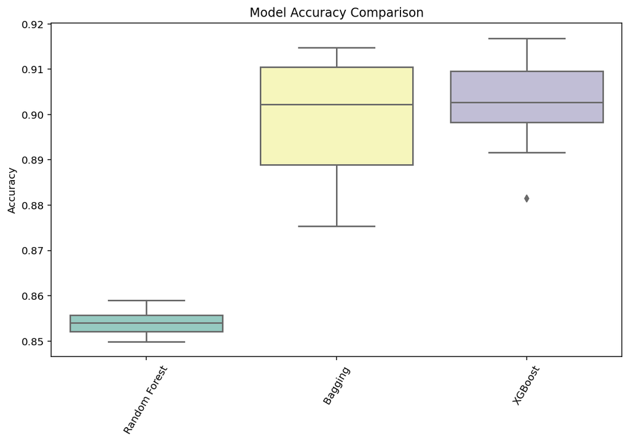

```python
my_acc = [rfc_acc, bc_acc, xgb_acc]
my_labels = ['Random Forest', 'Bagging', 'XGBoost']

fig, ax = plt.subplots(figsize=(10, 6))
sns.boxplot(data=my_acc, palette='Set3')
ax.set_xticklabels(my_labels, rotation=60)
ax.set_title('Model Accuracy Comparison')
ax.set_ylabel('Accuracy')
plt.show()
```

# 8 Classification with GridSearchCV (8 Points):

Replicate the classification from Q2 using GridsearchCV().

```python
from sklearn.model_selection import GridSearchCV
```

```python
# Add code here
params = {'n_estimators': [100, 200, 300],
            'max_depth': [3, 5, 7],
            'random_state': [1276]
            }

rfc_grid = GridSearchCV(rfc, params, cv=k, scoring='accuracy', n_jobs=-1)
rfc_grid.fit(X_train, y_train)
```

```
GridSearchCV(cv=10,
             estimator=RandomForestClassifier(max_depth=3, random_state=1276),
             n_jobs=-1,
             param_grid={'max_depth': [3, 5, 7],
                         'n_estimators': [100, 200, 300],
                         'random_state': [1276]},
             scoring='accuracy')
```

```python
#show the best hyperparameters for rfc
print(f"Best parameters for Random Forest: {rfc_grid.best_params_}")
```

```
Best parameters for Random Forest: {'max_depth': 7, 'n_estimators': 200, 'random_state': 1276}
```

```python
params = {'n_estimators': [100, 200, 300],
            'max_samples': [100, 200, 300],
            'random_state': [1276]
            }
bc_grid = GridSearchCV(bc, params, cv=k, scoring='accuracy', n_jobs=-1)

bc_grid.fit(X_train, y_train)
```

```
GridSearchCV(cv=10,
             estimator=BaggingClassifier(max_samples=100, n_estimators=100,
                                         random_state=1276),
             n_jobs=-1,
             param_grid={'max_samples': [100, 200, 300],
                         'n_estimators': [100, 200, 300],
                         'random_state': [1276]},
             scoring='accuracy')
```

```python
print(f"Best parameters for Bagging: {bc_grid.best_params_}")
```

```
Best parameters for Bagging: {'max_samples': 200, 'n_estimators': 100, 'random_state': 1276}
```

```python
params = {'n_estimators': [100, 200, 300],
            'max_depth': [3, 5, 7],
            'random_state': [1276]
            }
xgb_grid = GridSearchCV(xgb, params, cv=k, scoring='accuracy', n_jobs=-1)
xgb_grid.fit(X_train, y_train)
```

```
GridSearchCV(cv=10,
             estimator=XGBClassifier(base_score=None, booster=None,
                                     callbacks=None, colsample_bylevel=None,
                                     colsample_bynode=None,
                                     colsample_bytree=None, device=None,
                                     early_stopping_rounds=None,
                                     enable_categorical=False, eval_metric=None,
                                     feature_types=None, gamma=None,
                                     grow_policy=None, importance_type=None,
                                     interaction_constraints=None,
                                     learning_rate=None...
                                     max_cat_threshold=None,
                                     max_cat_to_onehot=None,
                                     max_delta_step=None, max_depth=3,
                                     max_leaves=None, min_child_weight=None,
                                     missing=nan, monotone_constraints=None,
                                     multi_strategy=None, n_estimators=100,
                                     n_jobs=None, num_parallel_tree=None,
                                     random_state=1276, ...),
             n_jobs=-1,
             param_grid={'max_depth': [3, 5, 7],
                         'n_estimators': [100, 200, 300],
                         'random_state': [1276]},
             scoring='accuracy')
```

```python
print(f"Best parameters for XGBoost: {xgb_grid.best_params_}")
```

```
Best parameters for XGBoost: {'max_depth': 3, 'n_estimators': 100, 'random_state': 1276}
```

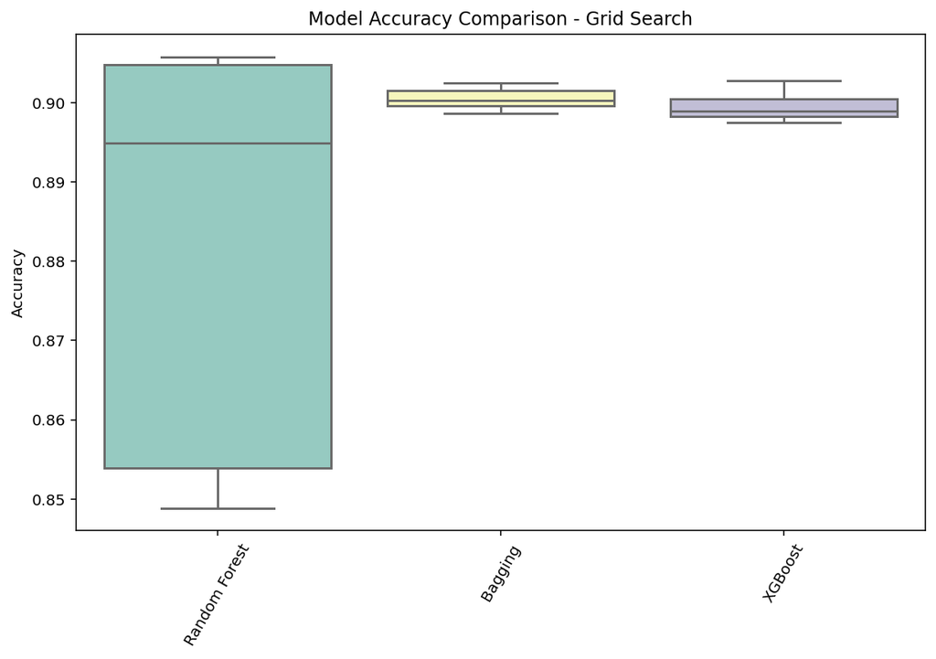

```python
rfc_results = rfc_grid.cv_results_['mean_test_score']
bc_results = bc_grid.cv_results_['mean_test_score']
xgb_results = xgb_grid.cv_results_['mean_test_score']

all = [rfc_results, bc_results, xgb_results]

fig, ax = plt.subplots(figsize=(10, 6))
sns.boxplot(data=all, palette='Set3')
ax.set_xticklabels(my_labels, rotation=60)
ax.set_title('Model Accuracy Comparison - Grid Search')
ax.set_ylabel('Accuracy')
plt.show()
```

# 9 Classification with RandomSearchCV (8 Points):

Replicate the classification from Q2 using RandomSearchCV().

```python
from sklearn.model_selection import RandomizedSearchCV
```

```python
# Add code here
params = {'n_estimators': [100, 200, 300],
            'max_depth': [3, 5, 7],
            'random_state': [1276]
            }

rfc_random = RandomizedSearchCV(rfc, params, cv=k, scoring='accuracy', n_jobs=-1)
rfc_random.fit(X_train, y_train)

print(f"Best parameters for Random Forest: {rfc_random.best_params_}")
```

```
Best parameters for Random Forest: {'random_state': 1276, 'n_estimators': 200, 'max_depth': 7}
```

```python
params = {'n_estimators': [100, 200, 300],
            'max_samples': [100, 200, 300],
            'random_state': [1276]
            }

bc_random = RandomizedSearchCV(bc, params, cv=k, scoring='accuracy', n_jobs=-1)
bc_random.fit(X_train, y_train)

print(f"Best parameters for Bagging: {bc_random.best_params_}")
```

```
Best parameters for Bagging: {'random_state': 1276, 'n_estimators': 100, 'max_samples': 200}
```

```python
params = {'n_estimators': [100, 200, 300],
            'max_depth': [3, 5, 7],
            'random_state': [1276]
            }

xgb_random = RandomizedSearchCV(xgb, params, cv=k, scoring='accuracy', n_jobs=-1)
xgb_random.fit(X_train, y_train)

print(f"Best parameters for XGBoost: {xgb_random.best_params_}")
```

```
Best parameters for XGBoost: {'random_state': 1276, 'n_estimators': 100, 'max_depth': 3}
```

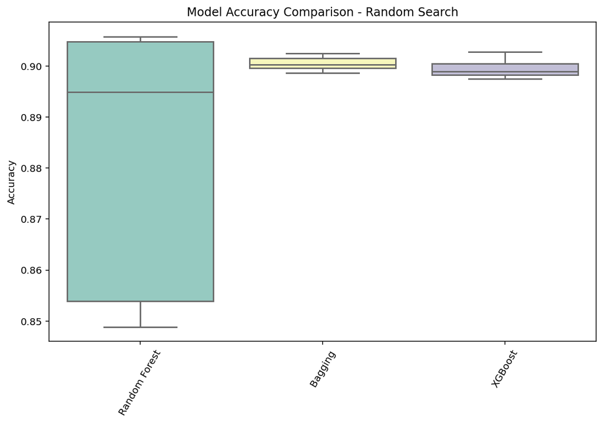

```python
rfc_rscores = rfc_random.cv_results_['mean_test_score']
bc_rscores = bc_random.cv_results_['mean_test_score']
xgb_rscores = xgb_random.cv_results_['mean_test_score']

all = [rfc_rscores, bc_rscores, xgb_rscores]

fig, ax = plt.subplots(figsize=(10, 6))
sns.boxplot(data=all, palette='Set3')
ax.set_xticklabels(my_labels, rotation=60)
ax.set_title('Model Accuracy Comparison - Random Search')
ax.set_ylabel('Accuracy')
plt.show()
```

# 10 Comparison and Analysis (5 Points):

Compare the results from Q2, Q3, and Q4. Describe the best hyperparameters for all three experiments.

### 10.0.1 Best Hyperparameters for Q3:

```python
print(f"Best parameters for Random Forest: {rfc_grid.best_params_}")
print(f"Best parameters for Bagging: {bc_grid.best_params_}")
print(f"Best parameters for XGBoost: {xgb_grid.best_params_}")
```

```
Best parameters for Random Forest: {'max_depth': 7, 'n_estimators': 200, 'random_state': 1276}
Best parameters for Bagging: {'max_samples': 200, 'n_estimators': 100, 'random_state': 1276}
Best parameters for XGBoost: {'max_depth': 3, 'n_estimators': 100, 'random_state': 1276}
```

### 10.0.2 Best Hyperparameters for Q4:

```python
print(f"Best parameters for Random Forest: {rfc_random.best_params_}")
print(f"Best parameters for Bagging: {bc_random.best_params_}")
print(f"Best parameters for XGBoost: {xgb_random.best_params_}")
```

```
Best parameters for Random Forest: {'random_state': 1276, 'n_estimators': 200, 'max_depth': 7}
Best parameters for Bagging: {'random_state': 1276, 'n_estimators': 100, 'max_samples': 200}
Best parameters for XGBoost: {'random_state': 1276, 'n_estimators': 100, 'max_depth': 3}
```